# Homework 3

Yu-Jen Lin

#### b04b01036@ntu.edu.tw

#### ——————————————————————————————————————————————————–

#### Set working directory

```r
setwd("~/R")
```

#### Read enviANDdensity.csv into R

```r
enviANDdensity <- read.csv(file="~/R/enviANDdensity.csv", header=TRUE)
```

Because we only need the data in “FishDensity..ind..1000m3.” and “CopepodDensity.ind..m3.”, I take these two columns out and set as “FishDensity” and “CopepodDensity” separately.

```r
FishDensity <- enviANDdensity$FishDensity..ind..1000m3.
CopepodDensity <- enviANDdensity$CopepodDensity.ind..m3.
```

###### ————————————————————————————————————————————————————————————————————————————-

#### 1. Compute the mean and SE(mean) for the fish and copepod densities (assuming all data points are independent) respectively, using both normal theory and non-parametric bootstrap. Plot the histogram of bootstrapped means with bootstrap 1000 times. (Normal theory simply means using the standard formula to estimate SE.)

#### mean and SE(mean)

```r
FishDensity.mean <- mean(FishDensity)
FishDensity.mean
```

```
## [1] 322.4516
```

```r
FishDensity.SE <- var(FishDensity)^0.5/length(FishDensity)^0.5
FishDensity.SE
```

```
## [1] 61.23107
```

```r
CopepodDensity.mean <- mean(CopepodDensity)
CopepodDensity.mean
```

```
## [1] 1972.374
```

```r
CopepodDensity.SE <- var(CopepodDensity)^0.5/length(FishDensity)^0.5
CopepodDensity.SE
```

```
## [1] 342.5549
```

#### non-parametric bootstrap

1. FishDensity bootstrap means

```r
FishDensity.bootstrap.means <- c() # set a vector to put the following sampling results
for (i in 1:1000) {
random <- ceiling(runif(34, min=0, max=34))
bootstrap.i <- FishDensity[random] # single sampling result
FishDensity.bootstrap.means[i] <- mean(bootstrap.i) # put every mean of every single result into the vector I've created
}
FishDensity.bootstrap.means <- append(FishDensity.bootstrap.means, FishDensity.mean) # add the mean calculated by normal theory (total:1001)
FishDensity.bootstrap.means.mean <- mean(FishDensity.bootstrap.means) # mean of bootstrap means
FishDensity.bootstrap.means.mean
```

```
## [1] 324.0179
```

```r
FishDensity.bootstrap.means.SE <- var(FishDensity.bootstrap.means)^0.5
FishDensity.bootstrap.means.SE
```

```
## [1] 60.80391
```

2. CopepodDensity bootstrap means

```r
CopepodDensity.bootstrap.means <- c() # set a vector to put the following sampling results
for (i in 1:1000) {
random <- ceiling(runif(34, min=0, max=34))
bootstrap.i <- CopepodDensity[random] # single sampling result
CopepodDensity.bootstrap.means[i] <- mean(bootstrap.i) # put every mean of every single result into the vector I've created
}
CopepodDensity.bootstrap.means <- append(CopepodDensity.bootstrap.means, CopepodDensity.mean) # add the mean calculated by normal theory (total:1001)
CopepodDensity.bootstrap.means.mean <- mean(CopepodDensity.bootstrap.means) # mean of bootstrap means
CopepodDensity.bootstrap.means.mean
```

```
## [1] 1950.922
```

```r
CopepodDensity.bootstrap.means.SE <- var(CopepodDensity.bootstrap.means)^0.5
CopepodDensity.bootstrap.means.SE
```

```
## [1] 332.2228
```

#### plot the histogram

1. FishDensity means by Bootstrap or Normal Theory

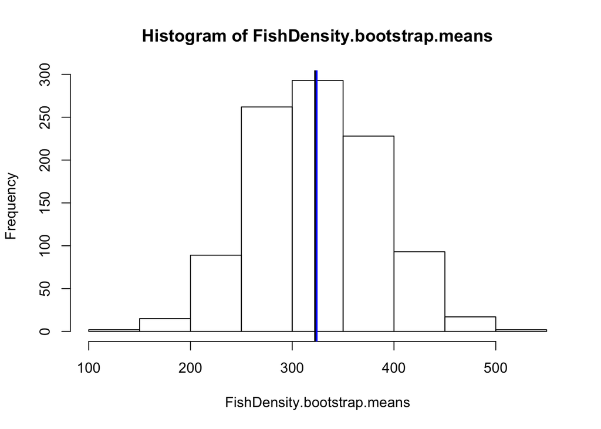

```r
hist(FishDensity.bootstrap.means)
abline(v = FishDensity.mean, col = "black", lwd = 2)
abline(v = FishDensity.bootstrap.means.mean, col = "blue", lwd = 2)
```

2. CopepodDensity means by Bootstrap or Normal Theory

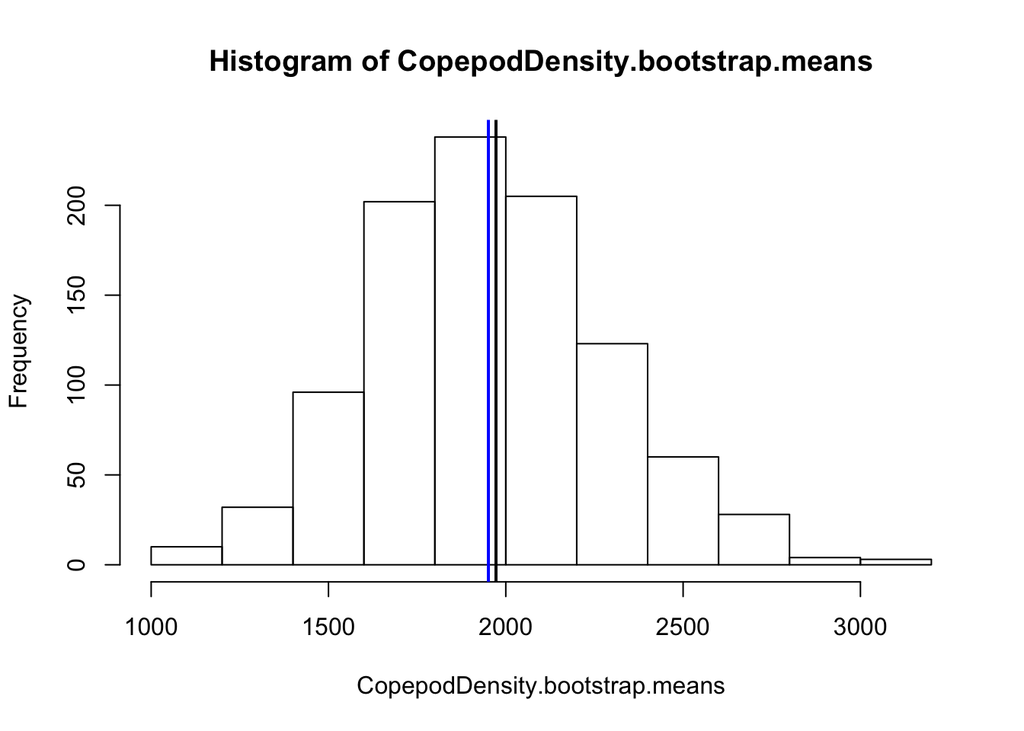

```r
hist(CopepodDensity.bootstrap.means)
abline(v = CopepodDensity.mean, col = "black", lwd = 2)
abline(v = CopepodDensity.bootstrap.means.mean, col = "blue", lwd = 2)
```

###### ————————————————————————————————————————————————————————————————————————————-

#### 2. Compute the median and bootstrapped SE(median) for the fish and copepod densities. Plot the histogram of bootstrapped medians with bootstrap 1000 times.

#### median

```r
FishDensity.median <- median(FishDensity)
FishDensity.median
```

```
## [1] 142.9266
```

```r
CopepodDensity.median <- median(CopepodDensity)
CopepodDensity.median
```

```
## [1] 1352.5
```

#### non-parametric bootstrap

1. FishDensity bootstrap medians

```r
FishDensity.bootstrap.medians <- c() # set a vector to put the following sampling results
for (i in 1:1000) {
random <- ceiling(runif(34, min=0, max=34))
bootstrap.i <- FishDensity[random] # single sampling result
FishDensity.bootstrap.medians[i] <- median(bootstrap.i) # put every median of every single result into the vector I've created
}
FishDensity.bootstrap.medians <- append(FishDensity.bootstrap.medians, FishDensity.median) # add the median calculated by normal theory (total:1001)
FishDensity.bootstrap.medians.median <- median(FishDensity.bootstrap.medians) # median of bootstrap medians
FishDensity.bootstrap.medians.median
```

```
## [1] 142.9266
```

```r
FishDensity.bootstrap.medians.SE <- var(FishDensity.bootstrap.medians)^0.5 ##length(FishDensity.bootstrap.medians)^0.5
FishDensity.bootstrap.medians.SE
```

```
## [1] 99.01332
```

2. CopepodDensity bootstrap medians

```r
CopepodDensity.bootstrap.medians <- c() # set a vector to put the following sampling results
for (i in 1:1000) {
random <- ceiling(runif(34, min=0, max=34))
bootstrap.i <- CopepodDensity[random] # single sampling result
CopepodDensity.bootstrap.medians[i] <- median(bootstrap.i) # put every median of every single result into the vector I've created
}
CopepodDensity.bootstrap.medians <- append(CopepodDensity.bootstrap.medians, CopepodDensity.median) # add the median calculated by normal theory (total:1001)
CopepodDensity.bootstrap.medians.median <- median(CopepodDensity.bootstrap.medians) # median of bootstrap medians
CopepodDensity.bootstrap.medians.median
```

```
## [1] 1352.5
```

```r
CopepodDensity.bootstrap.medians.SE <- var(CopepodDensity.bootstrap.medians)^0.5
CopepodDensity.bootstrap.medians.SE
```

```
## [1] 209.7274
```

#### plot the histogram

1. FishDensity medians by Bootstrap or Normal Theory

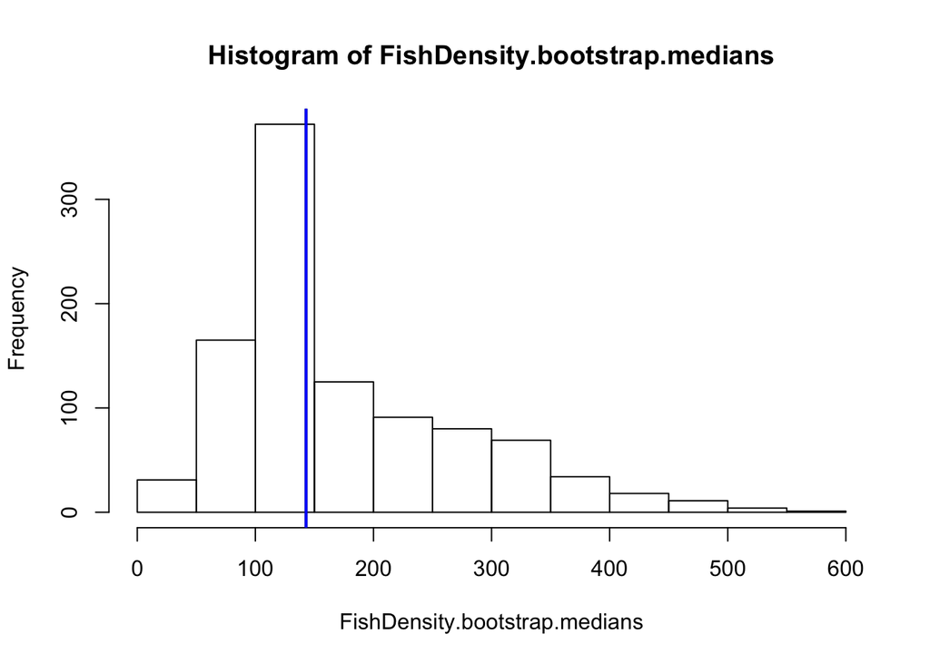

```r
hist(FishDensity.bootstrap.medians)
abline(v = FishDensity.median, col = "black", lwd = 2)
abline(v = FishDensity.bootstrap.medians.median, col = "blue", lwd = 2)
```

2. CopepodDensity medians by Bootstrap or Normal Theory

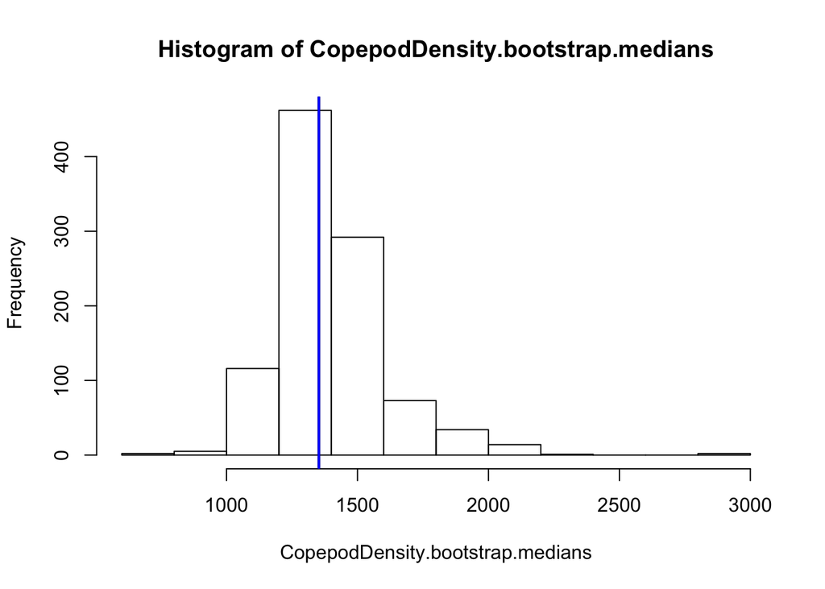

```r
hist(CopepodDensity.bootstrap.medians)
abline(v = CopepodDensity.median, col = "black", lwd = 2)
abline(v = CopepodDensity.bootstrap.medians.median, col = "blue", lwd = 2)
```

###### ————————————————————————————————————————————————————————————————————————————-

#### 1. & 2. Compare normal theory and bootstrap

```r
Fish.normal <- c(FishDensity.mean, FishDensity.SE, FishDensity.median, "-")
Fish.bootstrap <- c(FishDensity.bootstrap.means.mean, FishDensity.bootstrap.means.SE, FishDensity.bootstrap.medians.median,FishDensity.bootstrap.medians.SE)
Fish <- data.frame(Fish.normal,Fish.bootstrap)
rownames(Fish) <- c("mean", "SE(mean)", "median", "SE(median)" )
Fish
```

```
##                 Fish.normal Fish.bootstrap
## mean       322.451633316735      324.01791
## SE(mean)   61.2310707375046       60.80391
## median          142.9265688      142.92657
## SE(median)                -       99.01332
```

```r
Copepod.normal <- c(CopepodDensity.mean, CopepodDensity.SE, CopepodDensity.median, "-")
Copepod.bootstrap <- c(CopepodDensity.bootstrap.means.mean, CopepodDensity.bootstrap.means.SE, CopepodDensity.bootstrap.medians.median,CopepodDensity.bootstrap.medians.SE)
Copepod <- data.frame(Copepod.normal,Copepod.bootstrap)
rownames(Copepod) <- c("mean", "SE(mean)", "median", "SE(median)" )
Copepod
```

```
##              Copepod.normal Copepod.bootstrap
## mean       1972.37411764706         1950.9223
## SE(mean)   342.554903173053          332.2228
## median               1352.5         1352.5000
## SE(median)                -          209.7274
```

#### Compute the regression coefficients for

#### fish(y) = β0 + β1 * copepod(x).

Dimension of y -> (n,1) Dimension of β0 -> (n,1) Dimension of β1 -> (k+1,1) Dimension of X -> (n,k+1)

```r
n <- length(FishDensity)
k <- 1

y  <- matrix(FishDensity, nrow=n, ncol=1, byrow = TRUE) # put the original sample into y
x  <- matrix(c(rep(1, times=n),CopepodDensity), nrow=n, ncol=k+1, byrow = FALSE)  # put the original sample into x

β1 <- solve(t(x) %*% x) %*% t(x) %*% y
β1
```

```
##            [,1]
## [1,] 93.0646559
## [2,]  0.1162999
```

```r
β0 <- y - x %*% β1  # fish(y) = β0 + β1 * copepod(x)
```

Thus, through β1, I found the intercept of the regression line is 93.0647 and the slope of the regression line is 0.1163. y = 93.0647 + 0.1163*x

#### Plot fish (dependent) v.s. copepod (independent) and the regression line.

I plot the regression line I just computed in below. (blue) y = 93.0647 + 0.1163*x

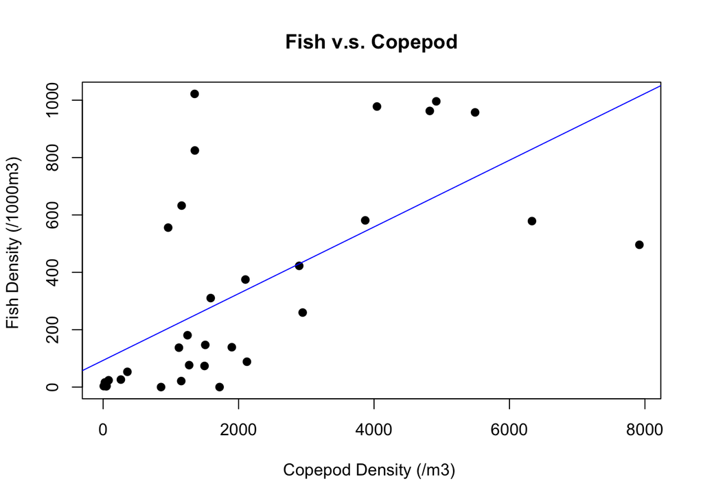

```r
plot(CopepodDensity, FishDensity, main="Fish v.s. Copepod",
    xlab="Copepod Density (/m3) ", ylab="Fish Density (/1000m3) ", pch=19)
abline(a=93.0647, b=0.1163, col="blue") # regression line (y~x) # the regression line I computed in previous step, a=intercept b=slope
```

#### bootstrapped SE(β0) and SE(β1).

```r
# set vectors to put the following sampling results
bootstrap.β0 <- c()
bootstrap.β1 <- c()

# set starting points
n.bt <- length(FishDensity)
k.bt <- 999

# bootstrap
for (i in 1:k.bt) {
random <- ceiling(runif(34, min=0, max=34))
bootstrap.Fish.i <- FishDensity[random] # single sampling result
bootstrap.Copepod.i <- CopepodDensity[random] # single sampling result

y.bt  <- matrix(bootstrap.Fish.i, nrow=n.bt, ncol=1, byrow = FALSE) # put the bootstrap sample into y.bt
x.bt  <- cbind(c(rep(1, times=n.bt)), as.matrix(bootstrap.Copepod.i)) # combine the new column into the x.bt

β1.bt <- solve(t(x.bt) %*% x.bt) %*% t(x.bt) %*% y.bt
bootstrap.β0[i] <- β1.bt[1] # intercept
bootstrap.β1[i] <- β1.bt[2] # slope
}

bootstrap.β0 <- append(bootstrap.β0, β1.bt[1]) # add the SE(β0) calculated by normal theory (total:1000)
bootstrap.β1 <- append(bootstrap.β1, β1.bt[2]) # add the SE(β1) calculated by normal theory (total:1000)

bootstrap.β0.SE <- var(bootstrap.β0)^0.5
bootstrap.β0.SE
```

```
## [1] 61.74531
```

```r
bootstrap.β1.SE <- var(bootstrap.β1)^0.5
bootstrap.β1.SE
```

```
## [1] 0.03056903
```

bootstrapped β0

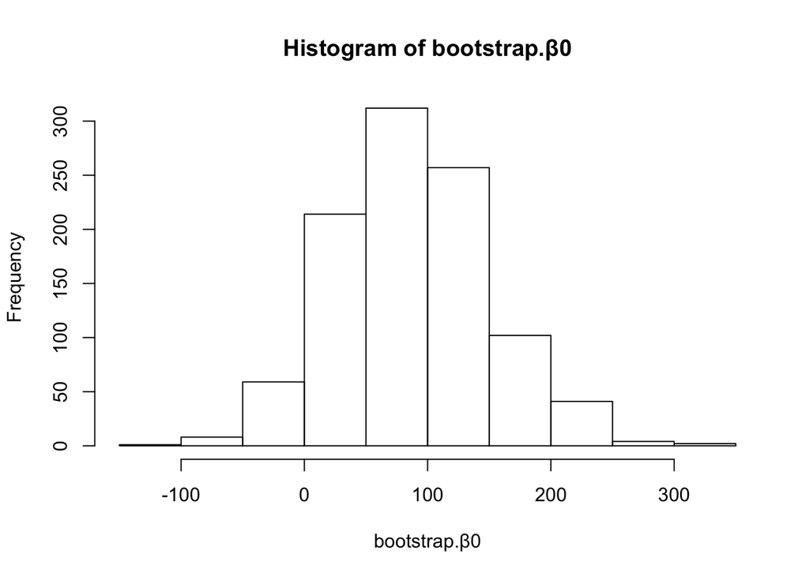

```r
hist(bootstrap.β0)
```

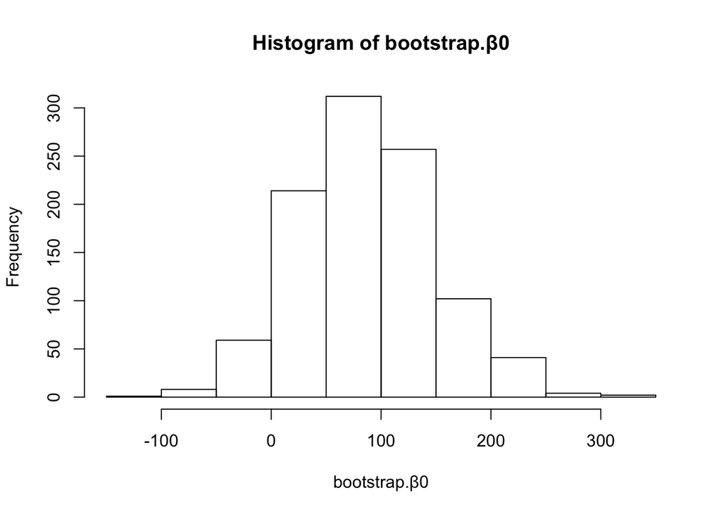

```r
hist(bootstrap.β0)
```